# HW 02 - Airbnb listings in Edinburgh

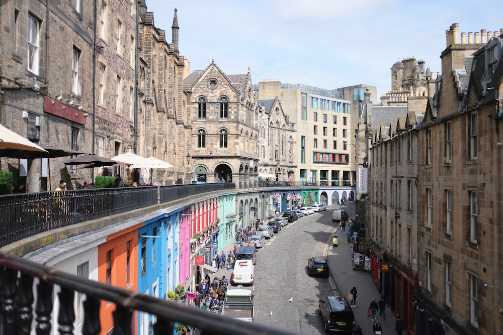

Photo by Madeleine Kohler on Unsplash

Once upon a time, people travelled all over the world, and some stayed in hotels and others chose to stay in other people’s houses that they booked through Airbnb.

Recent developments in Edinburgh regarding the growth of Airbnb and its impact on the housing market mean that a better understanding of Airbnb listings is needed. Using data provided by Airbnb, we can explore how Airbnb availability and prices vary by neighbourhood.

# Getting started

Open the project for this assignment in the course Posit Cloud workspace.

Open the R Markdown document `hw-02.Rmd` and **render** it before making any changes.

Make sure the document renders without errors. This is a useful first check that the project, packages, data, and files are all working correctly.

## Warm up

Before we introduce the data, let’s warm up with a simple exercise.

- Update the YAML, changing the author name to your name.
- Render the document.
- Open the rendered document and confirm that your name appears correctly.

🧶 ✅ *Throughout this assignment, remember to render your document regularly. After rendering, check the output to make sure your code, figures, and written responses appear as you expect.*

## Packages

We’ll use the **tidyverse** package for much of the data wrangling and visualization.

We will also use the **ggridges** package to make ridgeline plots.

You can load them by running the following:

```r
library(tidyverse)
library(ggridges)
```

If one of these packages is not installed, run the appropriate `install.packages()` command in your **Console**:

```r
install.packages("tidyverse")
install.packages("ggridges")
```

You only need to install a package once. Do not put `install.packages()` in the code you render for your assignment.

## Data

The Airbnb data for this assignment are stored in the `data` folder of your project.

Load the data using:

```r
edibnb <- read_csv("data/edibnb.csv")
```

You can view the dataset as a spreadsheet using the `View()` function.

Run this in the **Console** rather than in your R Markdown document:

```r
View(edibnb)
```

`View()` opens an interactive data viewer, so it does not make sense to include it in a rendered document.

You can see the names of the variables in the dataset using:

```r
names(edibnb)
```

# Exercises

**Hint:** The Markdown Quick Reference sheet has an example of inline R code that might be helpful. You can access it from the Help menu in RStudio. It is also referenced in this section of the [R Markdown Cookbook](https://bookdown.org/yihui/rmarkdown-cookbook/r-code.html).

1. ✏️ How many observations (rows) does the dataset have? Instead of hard coding the number in your answer, use **inline R code**.
2. ✏️ Run `View(edibnb)` in your Console to view the data in the data viewer. What does each row in the dataset represent?

**Hint:** It’s something you can book.

🧶 ✅ *Write your answers under Exercises 1 and 2, then render the document. Check the rendered document to make sure your answers appear correctly and that the inline R code in Exercise 1 displays a number rather than code.*

Each column represents a variable.

We can get a list of the variables in the data frame using the `names()` function.

```r
names(edibnb)
```

**Note:** The plot will give a warning about some observations with non-finite values for price being removed. Don’t worry about the warning. It simply means that some listings in the data don’t have prices available, so they can’t be plotted.

3. ✏️ Create a faceted histogram where each facet represents a neighbourhood and displays the distribution of Airbnb prices in that neighbourhood.

Think critically about whether it makes more sense to stack the facets on top of each other in a column, lay them out in a row, or wrap them around.

Along with your visualization, include your reasoning for the layout you chose for your facets.

```r
ggplot(data = ___, mapping = aes(x = ___)) +
  geom_histogram(binwidth = ___) +
  facet_wrap(~___)
```

Let’s deconstruct this code:

- `ggplot()` is the function we are using to build our plot in layers.
- In the first layer, we define the data frame. Then we define the mappings between variables in the dataset and the **aes**thetics of the plot, such as the x- and y-coordinates.
- In the next layer, we represent the data with **geom**etric shapes, in this case a histogram. You should decide what makes a reasonable bin width by trying a few options.
- In the final layer, we facet the data by neighbourhood.

🧶 ✅ *Complete the code for Exercise 3 and write your response underneath it. Render the document and check that the histogram appears correctly, the facets are readable, and your written explanation appears with the figure.*

4. ✏️ In this exercise you will explore the distribution of prices for neighbourhoods in Edinburgh and practice calculating summary statistics. In parts a–c you will create three pipelines.

**Hint:** 4a will give you the names you will use to filter the neighbourhoods before making the plot in 4b.

**New term:** Whenever you have more than one pipe `|>`, it is called a pipeline 😎.

### 4a.

Use a single pipeline to identify the neighbourhoods with the top five median listing prices.

**Hint:** Did your pipeline return `NA`s for the median listing prices? Use `?median` to find out how the argument `na.rm` might be useful in your code.

### 4b.

In another pipeline, filter the data for these five neighbourhoods and make ridgeline plots showing the distributions of listing prices in these neighbourhoods.

**Hint:** Check out the tutorial on [R Graph Gallery](https://r-graph-gallery.com/294-basic-ridgeline-plot.html) for an example of how to make a ridgeline plot.

### 4c.

✏️ In a third pipeline, calculate the minimum, mean, median, standard deviation, IQR, and maximum listing price in each of these neighbourhoods.

Use the visualization and summary statistics together to describe the distribution of listing prices in these neighbourhoods.

Your final answer for Exercise 4 should include **three pipelines**, one of which ends in a visualization, as well as a written interpretation.

🧶 ✅ *Complete all three parts of Exercise 4 and render the document. Check that all three pipelines run, the ridgeline plot is visible and readable, the summary statistics appear, and your interpretation refers to both the visualization and the numerical summaries.*

5. ✏️ Create a visualization that will help you compare the distribution of review scores (`review_scores_rating`) across neighbourhoods. You get to decide what type of visualization to create, and there is more than one correct answer! In your answer, include a brief interpretation of how Airbnb guests rate properties in general and how the neighbourhoods compare to each other in terms of their ratings.

**Tip:** Looking for ideas? Check out [R Graph Gallery](https://r-graph-gallery.com/index.html). What types of graphs could you use to display a distribution? Which ones have we learned so far in class?

🧶 ✅ *Complete Exercise 5 and render your document one final time. Read through the rendered document from beginning to end. Make sure all of your code runs, all figures and output appear correctly, and every exercise marked with ✏️ includes a written response before you submit your work.*